# Lab2_Arora

# **Lab 2: HipHop Lyrics**

```r
library(tidyverse)
```

```r
library(ggplot2)
library(here)
hiphop <- read_csv(here("Data","hiphop.csv"))
head(hiphop)
```

```
## # A tibble: 6 × 38
##   word    subj  sex     age ethnic   city county  intl vocal class…¹  folk  rock
##   <chr>   <chr> <chr> <dbl> <chr>   <dbl>  <dbl> <dbl> <dbl>   <dbl> <dbl> <dbl>
## 1 [to be… p15   Fema…    20 white   33283 1.16e6     0     0       0     0     1
## 2 [to be… p53   Fema…    17 white   34033 3.96e5     0     0       0     0     0
## 3 [to be… p136  Male     41 white    8789 5.87e4     0     2       0     0     0
## 4 [to be… p36   Fema…    18 white     712 1.49e5     0     0       0     1     1
## 5 [to be… p118  Fema…    18 white   24280 1.54e5     0     3       3     0     1
## 6 [to be… p106  Male     19 white  281262 5.06e5     0     0       0     0     0
## # … with 26 more variables: country <dbl>, pop <dbl>, alternative <dbl>,
## #   hiphop <dbl>, unclassifiable <dbl>, countyBlack <dbl>, jayz <dbl>,
## #   barkley <dbl>, boondocks <dbl>, monique <dbl>, bieber <dbl>,
## #   asianMove <dbl>, blackMove <dbl>, hispanicMove <dbl>, nativeMove <dbl>,
## #   SAAMEMove <dbl>, whiteMove <dbl>, blackWeekly <dbl>, jayz1 <dbl>,
## #   boondocks1 <dbl>, familiarity <dbl>, trial <dbl>, fam1 <dbl>,
## #   popularityScore <dbl>, numPreferredArtists <dbl>, …
## # ℹ Use `colnames()` to see all variable names
```

**The Dataset**

The data set “hiphop” contains results from a study conducted by a linguist at the University of Minnesota. The researcher was interested in predicting musical taste based on familiarity with African American English (AAE). 168 subjects participated in the study, and each was asked to define 64 different AAE terms. The definitions given were used to create a “familiarity” score for each subject for each term. This score quantifies how well the subject knew the term on a scale of 1-5 (1 = not at all, 5 = very well). Before tackling the problems, study the information on the following website, which includes a description of each variable:

http://conservancy.umn.edu/bitstream/handle/11299/116327/5/explanationAAEHiphopChesley.txt

**Assignment**

Summary

1. Provide a brief overview (2-4 sentences) of the dataset. (It is always good practice to start an analysis by getting a feel for the data and providing a quick summary for readers.) You do not need to show any source code for this question, although you probably want to use code to get information.

The dataset, ‘HipHop’ contains survey data for 168 participants (51 males and 117 females). Each participant defined 64 different AAE terms which were used to create the response variable, ‘familiarity’. The dataset consists of 10752 observations and 38 total variables which include demographic variables, social network variables, music variables, pop-cultural variables, artist variables and experimental items. The maximum and minimum age among the participants was 48 and 16 respectively.

2. Clean the dataset in whichever ways you see fit. This might mean adjusting variable type, for example from “character” to “factor”, or dealing with missing data.

```r
hiphop1 <- hiphop %>%
  mutate(numOverallArtists = replace(numOverallArtists, is.na(numOverallArtists), 0)) %>%
  mutate(numPreferredArtists = replace(numPreferredArtists, is.na(numPreferredArtists), 0)) %>%
  mutate(sex = factor(sex), ethnic = factor(ethnic))

# Since NA data was more than half the observations, instead of dropping the NA's they were converted to 0's
```

3. How many unique AAVE words were studied in this dataset?

```r
length(unique(hiphop$word))
```

```
## [1] 64
```

4. Make a new variable that recategorizes ethnic into only two groups, “white” and “non-white”, to simplify your data.

```r
hiphop1 <- hiphop1 %>%
  mutate(ethnicity =ifelse(ethnic=="white","white","non-white")) %>%
  mutate(ethnicity = factor(ethnicity))
```

5. What are the demographics of the people in this study? Investigate the variables sex, age, and ethnic and summarize your findings in 1-3 complete sentences.

```r
hiphop_dem <- hiphop1 %>%
  select(sex, subj, age, ethnicity)

hiphop_dem_1 <- unique(hiphop_dem)
summary(hiphop_dem_1)
```

```
##      sex          subj                age            ethnicity
##  Female:117   Length:168         Min.   :16.00   non-white: 33
##  Male  : 51   Class :character   1st Qu.:18.00   white    :135
##               Mode  :character   Median :19.00
##                                  Mean   :20.02
##                                  3rd Qu.:20.00
##                                  Max.   :48.00
```

6. Make at least two plots to display the demographic information of the subjects in this study. You do not need to discuss these plots, but make sure they are appropriate to the data types and have informative titles and axis labels.

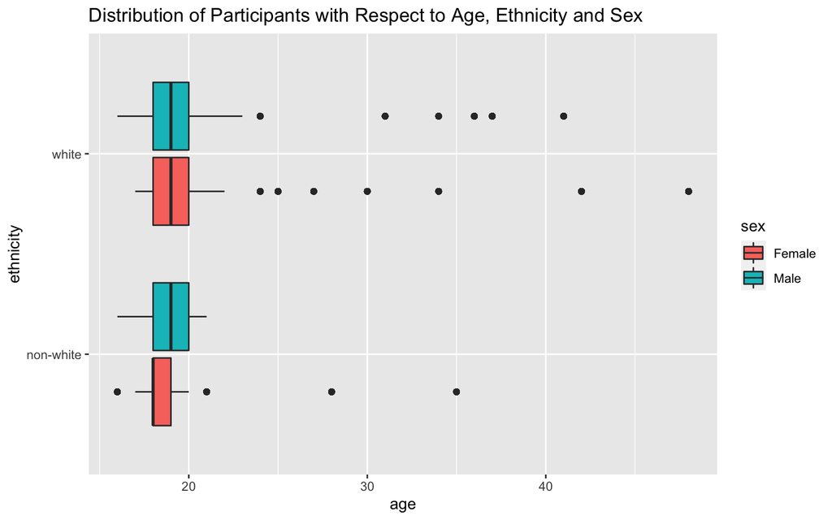

```r
hiphop1 %>%
  ggplot(aes(x= age, y= ethnicity, fill=sex)) +
  geom_boxplot() +
  labs(title = "Distribution of Participants with Respect to Age, Ethnicity and Sex")
```

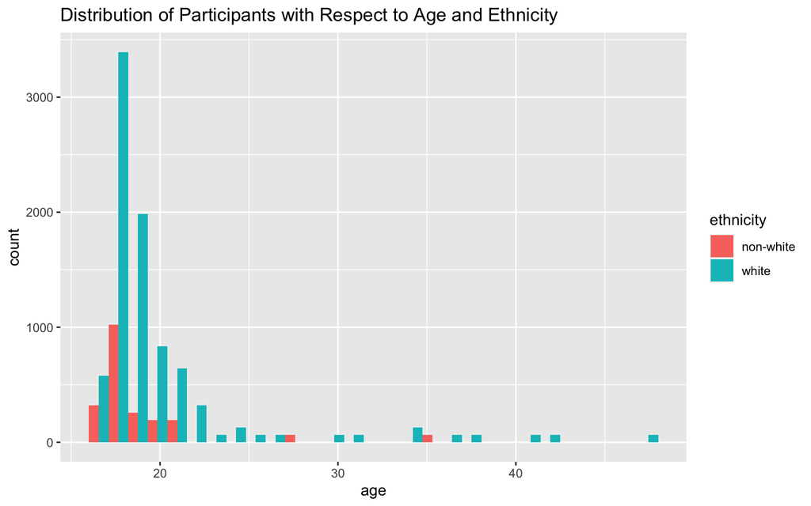

```r
hiphop1 %>%
  ggplot(aes(x= age, fill=ethnicity)) +
  geom_histogram(position = "dodge") +
  labs(title = "Distribution of Participants with Respect to Age and Ethnicity")
```

**Familiar words**

1. For each demographic group listed below, determine which word(s) in this study was the most and least familiar on average.
- People below the age of 20

```r
familiar_words <- hiphop1 %>%
  filter(age < 20) %>%
  group_by(word) %>%
  summarize(mean_familiarity = mean(familiarity))

familiar_words %>%
  slice_max(mean_familiarity,n =1)
```

```
## # A tibble: 1 × 2
##   word         mean_familiarity
##   <chr>                   <dbl>
## 1 off the hook             4.42
```

```r
familiar_words %>%
  slice_min(mean_familiarity,n=1)
```

```
## # A tibble: 1 × 2
##   word             mean_familiarity
##   <chr>                       <dbl>
## 1 catch the vapors             1.03
```

Most Popular Word (age < 20): off the hook

Least Popular Word (age < 20): catch the vapors

- Non-white women

```r
familiar_words_1 <- hiphop1 %>%
  filter(sex == "Female", ethnicity == "non-white") %>%
  group_by(word) %>%
  summarize(mean_familiarity_1 = mean(familiarity))

familiar_words_1 %>%
  slice_max(mean_familiarity_1,n =1)
```

```
## # A tibble: 1 × 2
##   word    mean_familiarity_1
##   <chr>                <dbl>
## 1 feel me               4.19
```

```r
familiar_words_1 %>%
  slice_min(mean_familiarity_1,n=1)
```

```
## # A tibble: 4 × 2
##   word              mean_familiarity_1
##   <chr>                          <dbl>
## 1 break someone out                  1
## 2 dukey rope                         1
## 3 plex                               1
## 4 rollie                             1
```

Most Popular Word (sex=‘Female’, ethnicity=‘non-white’): feel me

Least Popular Words (sex=‘Female’, ethnicity=‘non-white’): break someone out, dukey rope, plex and rollie

- White men above the age of 30

```r
familiar_words_2 <- hiphop1 %>%
  filter(sex == "Male", ethnicity == "white", age > 30) %>%
  group_by(word) %>%
  summarize(mean_familiarity_2 = mean(familiarity))

familiar_words_2 %>%
  slice_max(mean_familiarity_2,n =1)
```

```
## # A tibble: 1 × 2
##   word  mean_familiarity_2
##   <chr>              <dbl>
## 1 5-0                  4.2
```

```r
LM <- familiar_words_2 %>%
  slice_min(mean_familiarity_2,n=1)
LM
```

```
## # A tibble: 25 × 2
##    word              mean_familiarity_2
##    <chr>                          <dbl>
##  1 ay yo trip                         1
##  2 beezy                              1
##  3 break someone out                  1
##  4 catch the vapors                   1
##  5 crossroads                         1
##  6 crump                              1
##  7 dap                                1
##  8 dollar cab                         1
##  9 domino                             1
## 10 duckets                            1
## # … with 15 more rows
## # ℹ Use `print(n = ...)` to see more rows
```

Most Popular Word (sex=‘Male’, ethnicity=‘white’, age > 30): 5-0

Least Popular Words (sex=‘Male’, ethnicity=‘white’, age > 30): see variable LM

2. For each demographic comparison below, determine which music genre most differentiates the groups. That is, which genre had much higher average (mean or median) score in one group than the other.
- Male versus Female

```r
hiphop1 %>%
  distinct(subj, sex, intl, vocal, classical, folk, rock, country, pop, alternative, hiphop, unclassifiable) %>%
  group_by(sex) %>%
  summarize(mean_intl = mean(intl), mean_vocal = mean(vocal), mean_classical = mean(classical), mean_folk = mean(folk), mean_rock = mean(rock), mean_country = mean(country), mean_pop = mean(pop), mean_alternative = mean(alternative), mean_hiphop = mean(hiphop), mean_unclassifiable = mean(unclassifiable)) %>%
  pivot_longer(mean_intl:mean_unclassifiable, names_to = 'Genre', values_to = 'Mean_Genre') %>%
  pivot_wider(names_from = sex, values_from = Mean_Genre) %>%
  mutate(Diff = abs(Female-Male)) %>%
  arrange(desc(Diff))
```

```
## # A tibble: 10 × 4
##    Genre               Female   Male    Diff
##    <chr>                <dbl>  <dbl>   <dbl>
##  1 mean_rock           1.93   3.06   1.13
##  2 mean_vocal          0.880  1.57   0.688
##  3 mean_country        0.786  0.392  0.394
##  4 mean_pop            1.30   1.10   0.201
##  5 mean_intl           0.444  0.255  0.190
##  6 mean_classical      0.752  0.941  0.189
##  7 mean_hiphop         1.62   1.53   0.0945
##  8 mean_alternative    2.21   2.16   0.0568
##  9 mean_unclassifiable 0.0598 0.0392 0.0206
## 10 mean_folk           0.402  0.392  0.00955
```

Rock differentiates the most between Males and Females

- White versus Non-White

```r
hiphop1 %>%
  group_by(ethnicity) %>%
  distinct(subj, sex, intl, vocal, classical, folk, rock, country, pop, alternative, hiphop, unclassifiable) %>%
  summarize(mean_intl = mean(intl), mean_vocal = mean(vocal), mean_classical = mean(classical), mean_folk = mean(folk), mean_rock = mean(rock), mean_country = mean(country), mean_pop = mean(pop), mean_alternative = mean(alternative), mean_hiphop = mean(hiphop), mean_unclassifiable = mean(unclassifiable)) %>%
  pivot_longer(mean_intl:mean_unclassifiable, names_to = 'Genre', values_to = 'Mean_Genre') %>%
  pivot_wider(names_from = ethnicity, values_from = Mean_Genre) %>%
  mutate(Diff = abs(white-`non-white`)) %>%
  arrange(desc(Diff))
```

```
## # A tibble: 10 × 4
##    Genre               `non-white`  white   Diff
##    <chr>                     <dbl>  <dbl>  <dbl>
##  1 mean_intl                1.67   0.0741 1.59
##  2 mean_rock                1.06   2.57   1.51
##  3 mean_alternative         1.24   2.43   1.19
##  4 mean_hiphop              2.18   1.45   0.730
##  5 mean_vocal               0.667  1.19   0.526
##  6 mean_country             0.273  0.763  0.490
##  7 mean_folk                0.182  0.452  0.270
##  8 mean_classical           0.848  0.8    0.0485
##  9 mean_unclassifiable      0.0909 0.0444 0.0465
## 10 mean_pop                 1.27   1.23   0.0431
```

Intl differentiates the most between White and Non-White

- Age below 21 versus age 21+

```r
hiphop1 <- hiphop1 %>%
  mutate(age1 =ifelse(age < 21,"Below 21","Above 21")) %>%
  mutate(age1 = factor(age1))

hiphop1 %>%
  group_by(age1) %>%
  distinct(subj, sex, intl, vocal, classical, folk, rock, country, pop, alternative, hiphop, unclassifiable) %>%
  summarize(mean_intl = mean(intl), mean_vocal = mean(vocal), mean_classical = mean(classical), mean_folk = mean(folk), mean_rock = mean(rock), mean_country = mean(country), mean_pop = mean(pop), mean_alternative = mean(alternative), mean_hiphop = mean(hiphop), mean_unclassifiable = mean(unclassifiable)) %>%
  pivot_longer(mean_intl:mean_unclassifiable, names_to = 'Genre', values_to = 'Mean_Genre') %>%
  pivot_wider(names_from = age1, values_from = Mean_Genre) %>%
  mutate(Diff = abs(`Above 21`-`Below 21`)) %>%
  arrange(desc(Diff))
```

```
## # A tibble: 10 × 4
##    Genre               `Above 21` `Below 21`   Diff
##    <chr>                    <dbl>      <dbl>  <dbl>
##  1 mean_alternative        2.5        2.12   0.381
##  2 mean_intl               0.118      0.455  0.338
##  3 mean_hiphop             1.35       1.66   0.304
##  4 mean_vocal              0.941      1.13   0.186
##  5 mean_classical          0.882      0.791  0.0913
##  6 mean_rock               2.32       2.26   0.0623
##  7 mean_unclassifiable     0.0882     0.0448 0.0435
##  8 mean_pop                1.21       1.25   0.0404
##  9 mean_folk               0.412      0.396  0.0162
## 10 mean_country            0.676      0.664  0.0123
```

Alternative differentiates the most between Ages above and below 21

**Use the data**

A former Canadian child TV star named Aubrey Graham is interested in switching careers to become a rapper. Aubrey hires you to consult the hiphop dataset to help compose his new songs.

Note: There is no single right answer to these questions. You will need to think about how you want to address the question, and do the appropriate variable adjustments and calculations to come up with a reasonable answer.

1. Aubrey hopes that his songs will be perceived as authentically hiphop. He hopes his lyrics will be recognizeable to those who describe themselves as hiphop fans, but less recognizeable to those who do not consider themselves fans. Suggest some words or phrases that Aubrey should try to use, and some words he should avoid.

```r
fans <- hiphop1 %>%
 distinct(subj, hiphop, word, familiarity) %>%
  filter(hiphop >= quantile(hiphop,0.90)) %>%
  group_by(word) %>%
  summarise(mean_familiarity_3 = mean(familiarity)) %>%
  slice_max(mean_familiarity_3, n = 10)


nonfans <- hiphop1 %>%
  distinct(subj, hiphop, word, familiarity) %>%
  filter(hiphop <= quantile(hiphop,0.10)) %>%
  group_by(word) %>%
  summarise(mean_familiarity_3 = mean(familiarity)) %>%
  slice_max(mean_familiarity_3, n = 10)

nonfans
```

```
## # A tibble: 10 × 2
##    word          mean_familiarity_3
##    <chr>                      <dbl>
##  1 off the hook                4.34
##  2 feel me                     4.11
##  3 boo                         3.43
##  4 hella                       3.43
##  5 ballin'                     2.65
##  6 player hater                2.57
##  7 make it rain                2.44
##  8 what it do                  2.43
##  9 dun                         2.41
## 10 straight cash               2.39
```

```r
anti_join(fans, nonfans, by = "word")
```

```
## # A tibble: 3 × 2
##   word        mean_familiarity_3
##   <chr>                    <dbl>
## 1 finna                     3.83
## 2 What it is?               3.33
## 3 5-0                       3.22
```

Words to choose: finna, what it is?, 5-0

Words to avoid: off the hook, feel me, boo

2. Although Aubrey wants to be authentic, he also hopes to sell records, of course. Two titles have been suggested for his first album: “Hotline Boo” or “Hella Bling”. Based on the dataset, which will appeal more to the higher population areas? Make at least one plot to support your answer.

```r
summary(hiphop1$county)
```

```
##    Min. 1st Qu.  Median    Mean 3rd Qu.    Max.
##       0   99905  331582  509216  959521 3053793
```

```r
album <- hiphop1 %>%
  mutate(county = cut(county, breaks = c(0,99905,331582,3053793), labels=c('Small', 'Medium', 'Large'))) %>%
  filter(word == c('boo','hella')) %>%
  group_by(word, county) %>%
  summarize(pop_appeal = sum(fam1)) %>%
  drop_na()
```

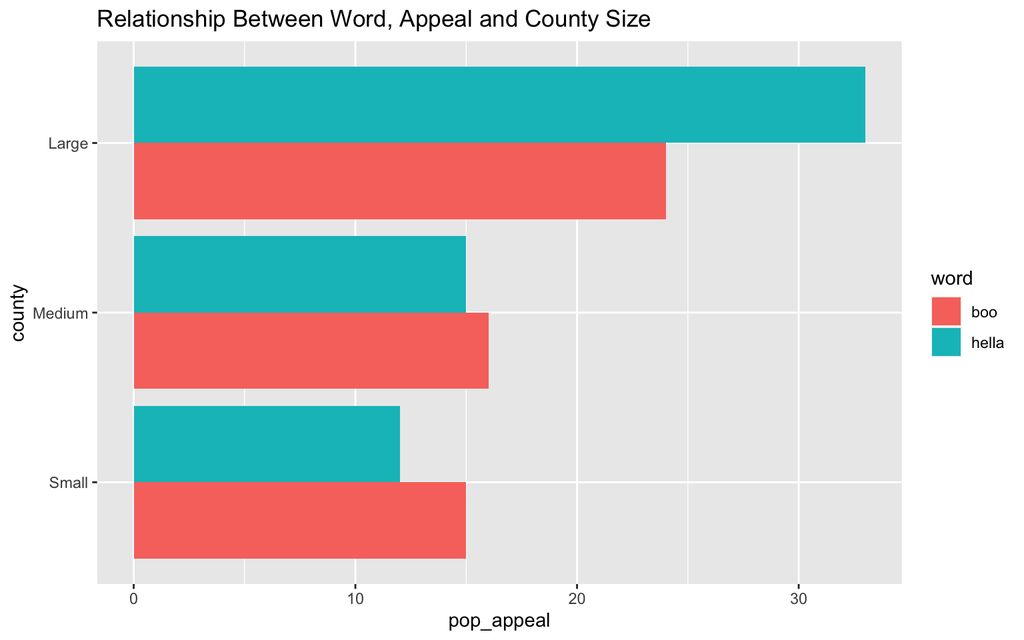

```r
album %>%
  ggplot(aes(x=pop_appeal, y=county, fill=word)) +
  geom_col(position = 'dodge') +
  labs(title = "Relationship Between Word, Appeal and County Size")
```

Aubrey should pick ‘Hella Bling’ as his album title considering this dataset because the word ‘Hella’ has a greater appeal than ‘Boo’ in larger counties. However, since the words ‘Bling’ and ‘Hotline’ are not in the dataset more investigation is needed to be conducted!

3. Aubrey’s true life dream is to collaborate with his fellow Canadian musician Justin Bieber. Luckily, he knows that Bieber himself was one of the subjects in this study! You know that Bieber is a white male, aged 17-23 at the time of the study, from a relatively small town (10,000-60,000 people) in Ontario.

   Determine which subject is secretly Bieber, and justify your answer.

```r
hiphop1 %>%
  filter(sex == 'Male', ethnicity == 'white', (age >= 17 & age <= 23), (city>=10000 & city <= 60000)) %>%
  arrange(desc(bieber)) %>%
  filter(bieber > 4)%>%
  filter(pop >= 3 )%>%
  head(1)
```

```
## # A tibble: 1 × 40
##   word     subj  sex     age ethnic  city county  intl vocal class…¹  folk  rock
##   <chr>    <chr> <fct> <dbl> <fct>  <dbl>  <dbl> <dbl> <dbl>   <dbl> <dbl> <dbl>
## 1 [to be]… p17   Male     18 white  56377 331582     0     1       0     0     1
## # … with 28 more variables: country <dbl>, pop <dbl>, alternative <dbl>,
## #   hiphop <dbl>, unclassifiable <dbl>, countyBlack <dbl>, jayz <dbl>,
## #   barkley <dbl>, boondocks <dbl>, monique <dbl>, bieber <dbl>,
## #   asianMove <dbl>, blackMove <dbl>, hispanicMove <dbl>, nativeMove <dbl>,
## #   SAAMEMove <dbl>, whiteMove <dbl>, blackWeekly <dbl>, jayz1 <dbl>,
## #   boondocks1 <dbl>, familiarity <dbl>, trial <dbl>, fam1 <dbl>,
## #   popularityScore <dbl>, numPreferredArtists <dbl>, …
## # ℹ Use `colnames()` to see all variable names
```